# IE48B Homework 2 Rmd- SÜLEYMAN TURANCAN BURUCU

Süleyman Turancan Burucu

11/21/2021

# Penalized Regression Approaches for Time Series Representation

## **1. Reading the Data and Visualization**

> In brief, this homework explains how we can construct some penalized regression approaches for time series. First of all, we have constrcuted 1D Fused Lasso representation with k = 10 and found the best lambda values for each time series. Then, we have constructed regression tree with different maxdepth values. Then, we have calculated the MSE values between for each time series on the dataset for 1D Fused Lasso model with best lambda value and the regression tree model with best maxdepth value. Moreover, we have created 1-nearest-neighborhood (1-NN) model. Also, we have checked the Euclidian distances between the excluded points for each model; 1D Fused Lasso, regression tree, and 1-NN. Finally, we have predicted the excluded points’ classes and checked whether we made predictions correct or not, and calculated accuracy values fore ach class

### **Question - 1**

Firstly, we are going to exclude each 1 observation from 10 observations, i.e. k = 10, for each time series to test 1D Fused Lasso model on the excluded data. Yet, exclusion didn’t mean that we have excluded the point permanently, we have just used these excluded points on our representations to check our representations and their results. Then, we needed to find the optimal lambda values for each time series to complete 1D Fused Lasso model. Yet, as you can see from the plots, the minimum lambda values didn’t give the best result since it causes overly fitted values for the predicted values; therefore, we had to use 1-standard-error rule and use the lambda values giving 1-standard-error values. Let’s check:

[output not shown]

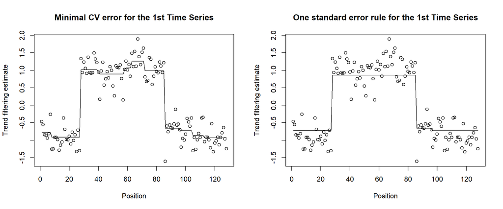

[output not shown]

[output not shown]

[output not shown]

[output not shown]

[output not shown]

[output not shown]

[output not shown]

[output not shown]

[output not shown]

[output not shown]

[output not shown]

[output not shown]

[output not shown]

[output not shown]

[output not shown]

[output not shown]

[output not shown]

[output not shown]

[output not shown]

[output not shown]

[output not shown]

[output not shown]

[output not shown]

[output not shown]

[output not shown]

[output not shown]

[output not shown]

[output not shown]

[output not shown]

```
##       1D Fused Lasso Model for Time Series Best Lambda Values
##  [1,]                                    1           5.153002
##  [2,]                                    2           3.683189
##  [3,]                                    3           1.767117
##  [4,]                                    4           2.709997
##  [5,]                                    5           4.057839
##  [6,]                                    6           3.058353
##  [7,]                                    7           2.894342
##  [8,]                                    8           4.536960
##  [9,]                                    9           3.926837
## [10,]                                   10           3.998243
## [11,]                                   11           3.325834
## [12,]                                   12           2.874310
## [13,]                                   13           3.030634
## [14,]                                   14           4.256197
```

[output cut: 16 more lines]

### **Question - 2**

After creating 1D Fused Lasso model, we have tried our best to represent each time series with regression trees. These regression tree models are chosen by checking the models with the least standard error (xerror) among the models that have maxdepth=1,2,3,4,5,6,7,8 values and cp=0. Let’s look at the models:

```
##    Best maxdepth parameter value CV Error Value
## 1:                             2       0.130567
```

[figure not shown]

```
##    Best maxdepth parameter value CV Error Value
## 1:                             8      0.1635141
```

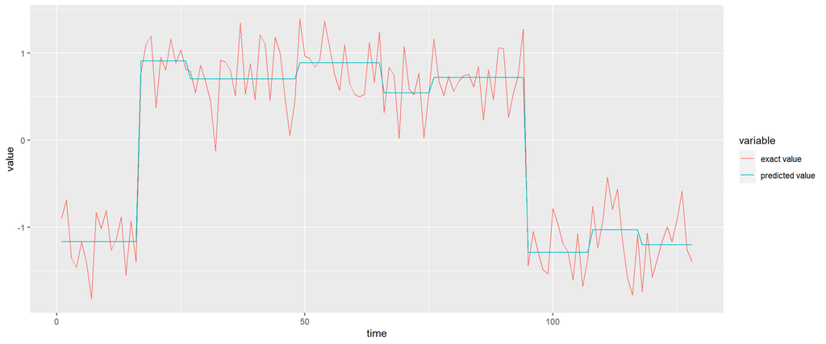

```
##    Best maxdepth parameter value CV Error Value
## 1:                             2      0.1475748
```

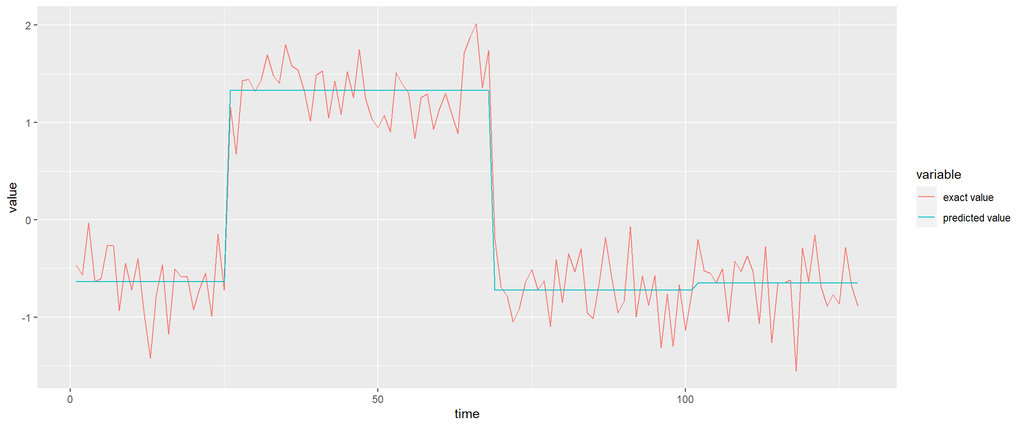

```
##    Best maxdepth parameter value CV Error Value
## 1:                             2      0.1576363
```

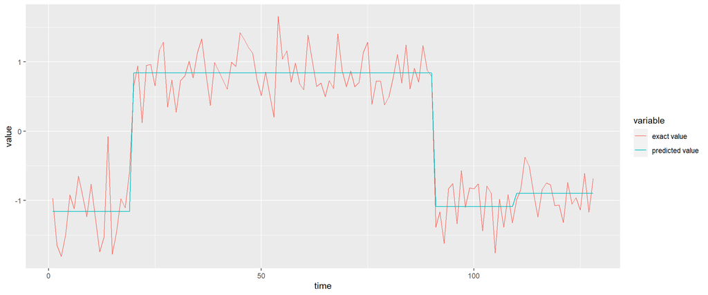

```
##    Best maxdepth parameter value CV Error Value
## 1:                             5       0.168621
```

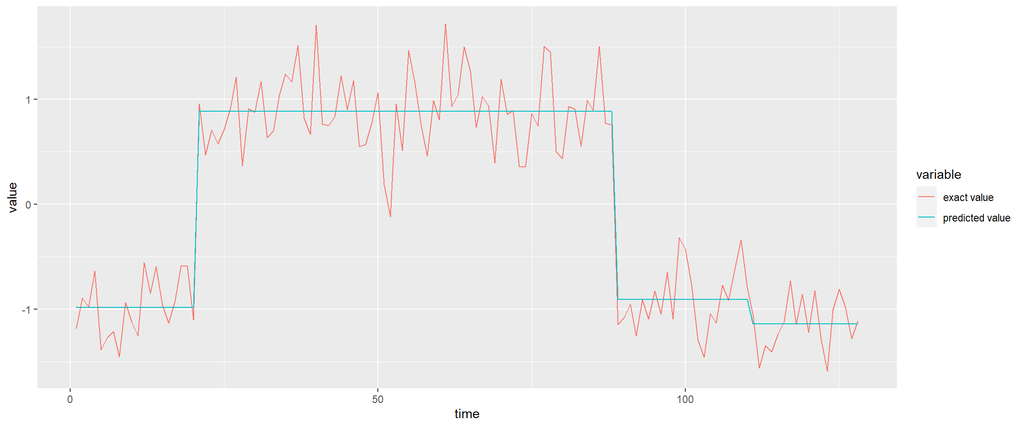

```
##    Best maxdepth parameter value CV Error Value
## 1:                             4      0.2862973
```

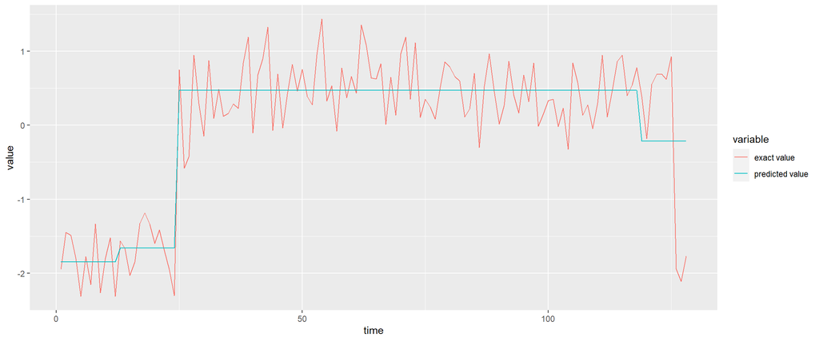

```
##    Best maxdepth parameter value CV Error Value
## 1:                             5      0.1323783
```

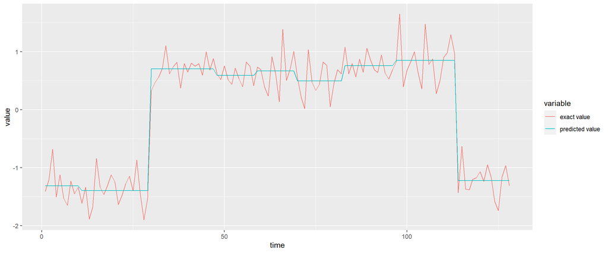

```
##    Best maxdepth parameter value CV Error Value
## 1:                             2      0.1622874
```

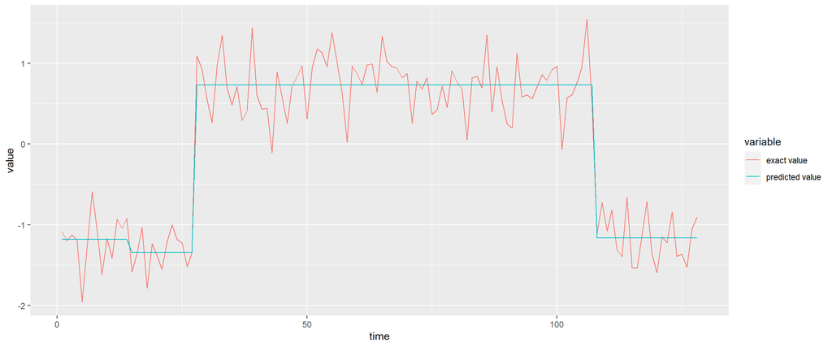

```
##    Best maxdepth parameter value CV Error Value
## 1:                             7      0.1635767
```

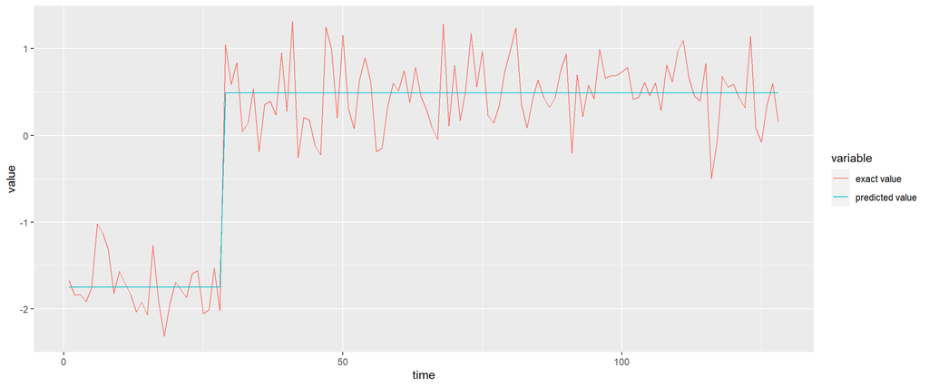

```
##    Best maxdepth parameter value CV Error Value
## 1:                             2      0.1893544
```

[figure not shown]

```
##    Best maxdepth parameter value CV Error Value
## 1:                             5      0.2872307
```

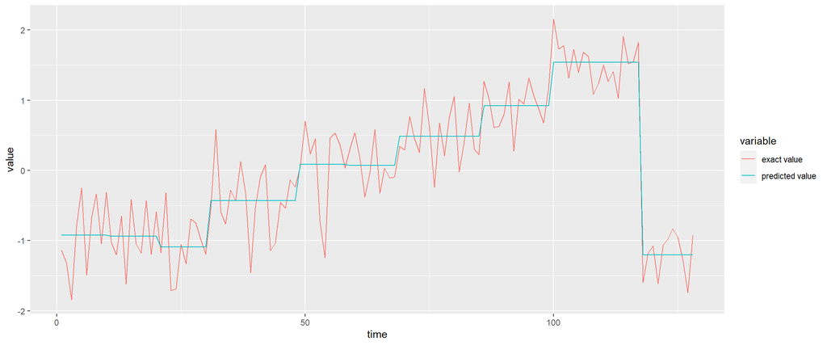

```
##    Best maxdepth parameter value CV Error Value
## 1:                             8      0.3912164
```

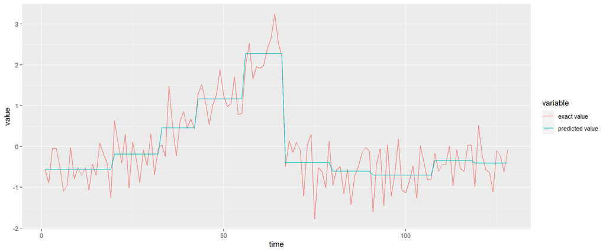

```
##    Best maxdepth parameter value CV Error Value
## 1:                             8      0.2393362
```

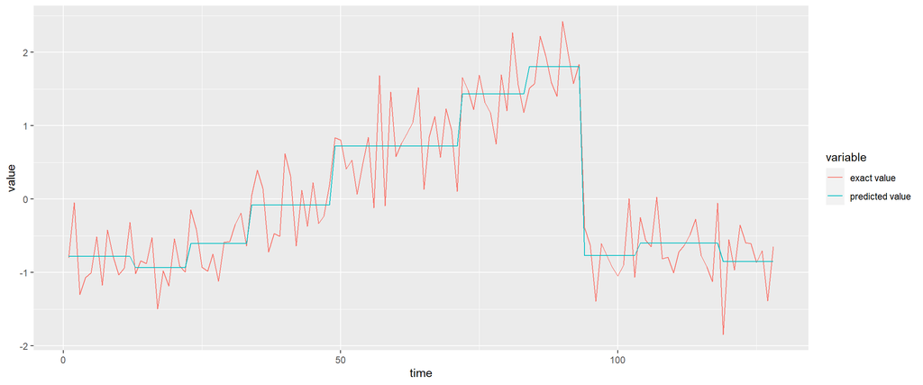

```
##    Best maxdepth parameter value CV Error Value
## 1:                             8      0.2858082
```

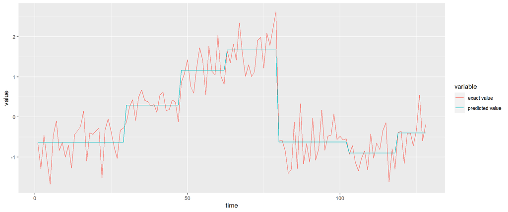

```
##    Best maxdepth parameter value CV Error Value
## 1:                             6       0.377507
```

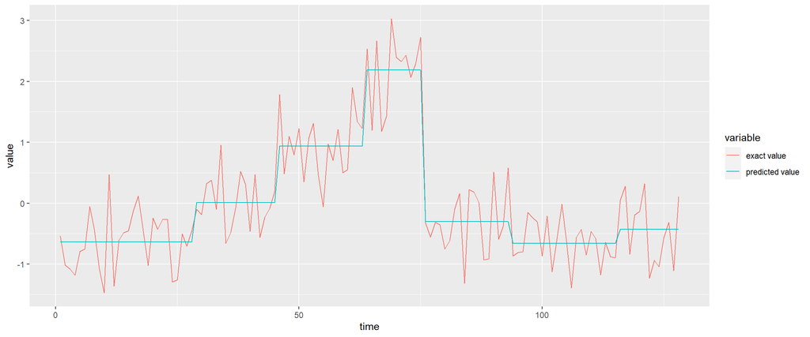

```
##    Best maxdepth parameter value CV Error Value
## 1:                             7      0.2911865
```

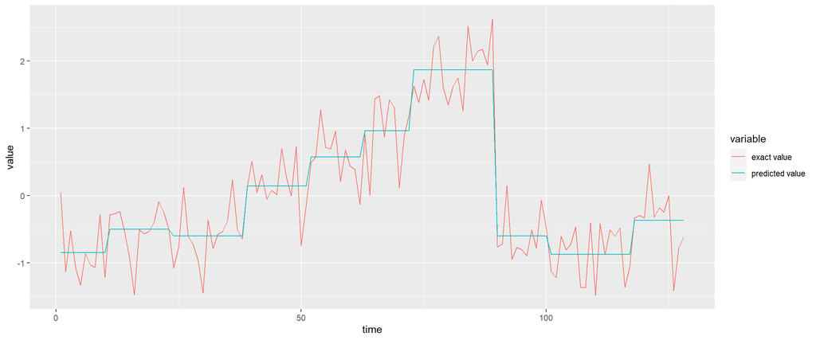

```
##    Best maxdepth parameter value CV Error Value
## 1:                             7      0.3709011
```

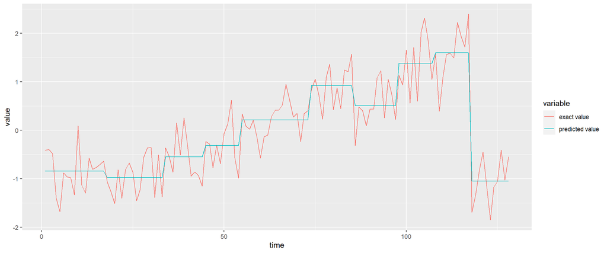

```
##    Best maxdepth parameter value CV Error Value
## 1:                             5      0.1682792
```

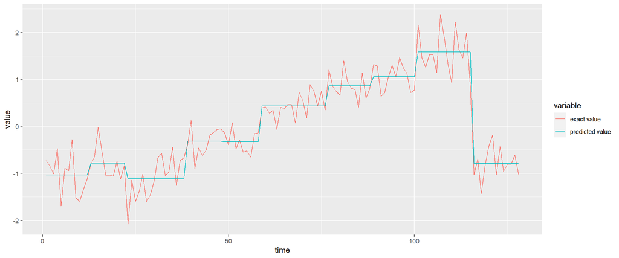

```
##    Best maxdepth parameter value CV Error Value
## 1:                             7      0.3218041
```

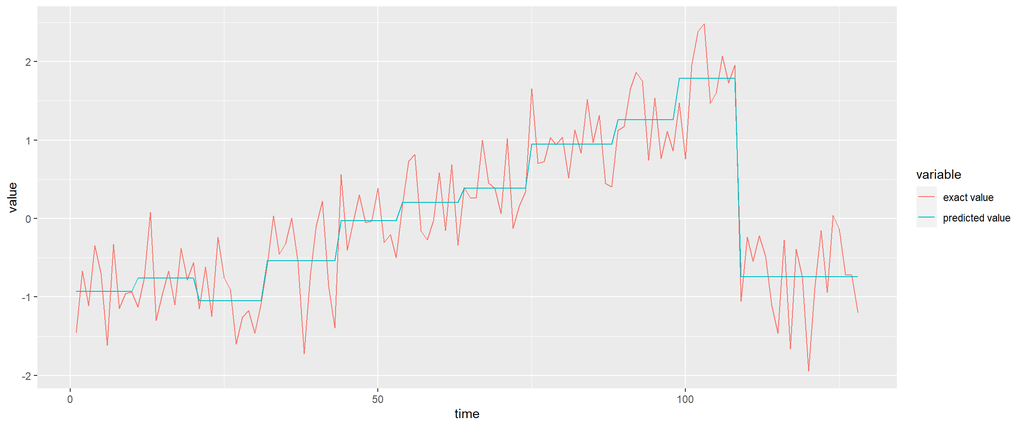

```
##    Best maxdepth parameter value CV Error Value
## 1:                             2       0.237288
```

[figure not shown]

```
##    Best maxdepth parameter value CV Error Value
## 1:                             6      0.2565149
```

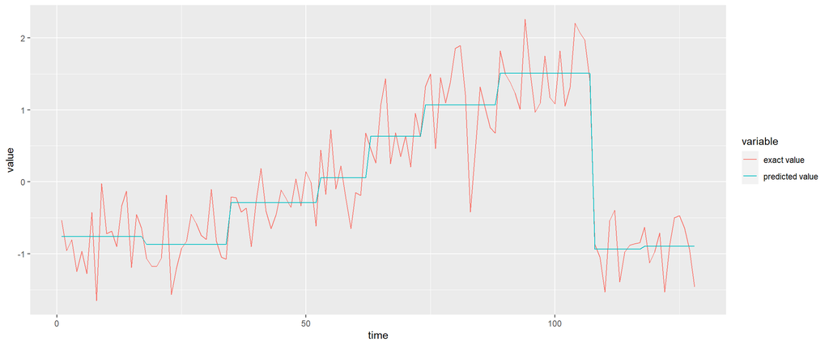

```
##    Best maxdepth parameter value CV Error Value
## 1:                             7      0.4383276
```

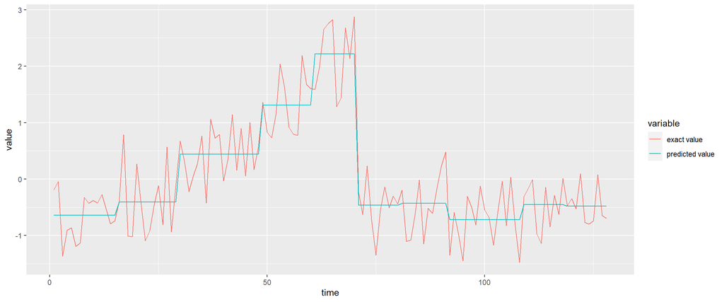

```
##    Best maxdepth parameter value CV Error Value
## 1:                             8       0.258206
```

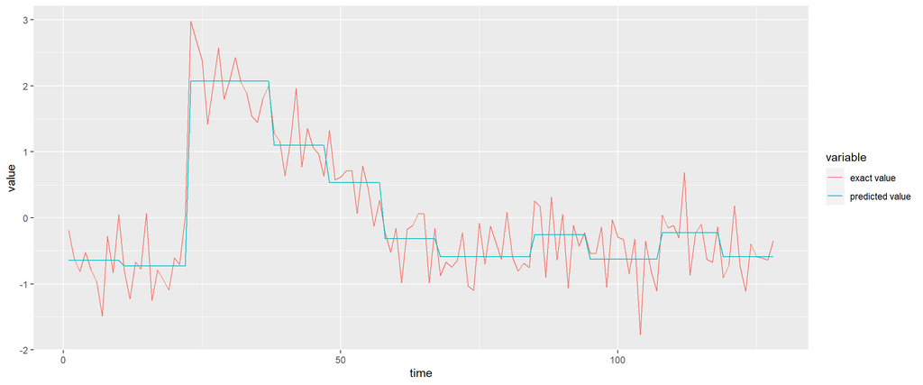

```
##    Best maxdepth parameter value CV Error Value
## 1:                             7      0.3126709
```

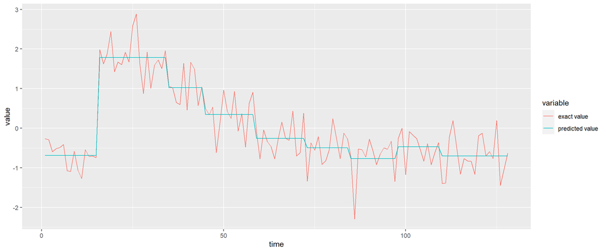

```
##    Best maxdepth parameter value CV Error Value
## 1:                             4      0.2740173
```

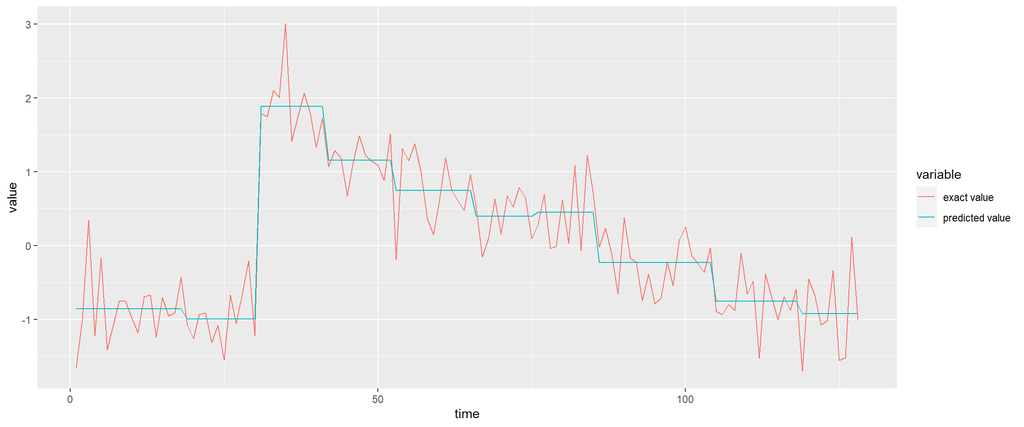

```
##    Best maxdepth parameter value CV Error Value
## 1:                             5      0.2987129
```

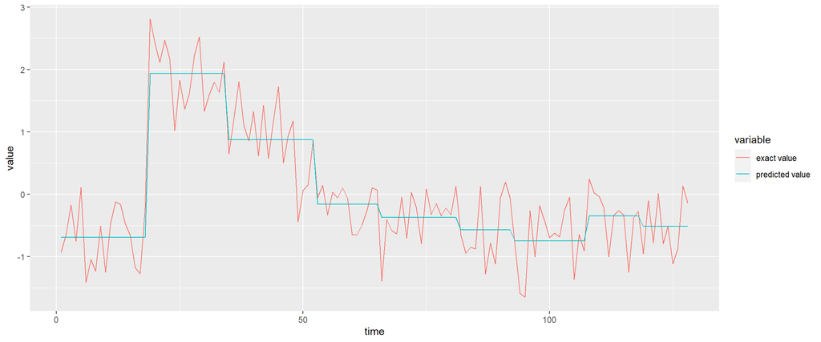

```
##    Best maxdepth parameter value CV Error Value
## 1:                             8      0.2628767
```

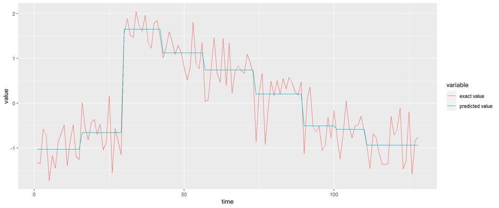

```
##    Best maxdepth parameter value CV Error Value
## 1:                             6      0.3030731
```

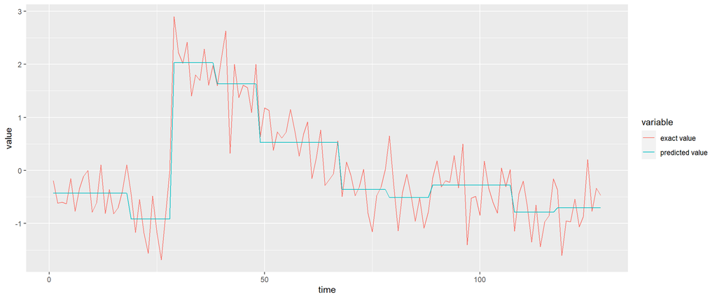

```
##    Best maxdepth parameter value CV Error Value
## 1:                             4      0.3319198
```

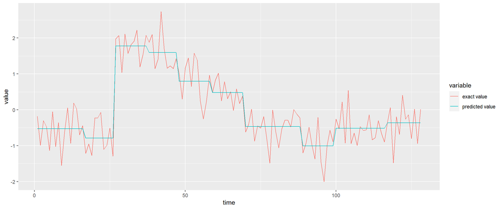

```
##    Best maxdepth parameter value CV Error Value
## 1:                             6      0.2745398
```

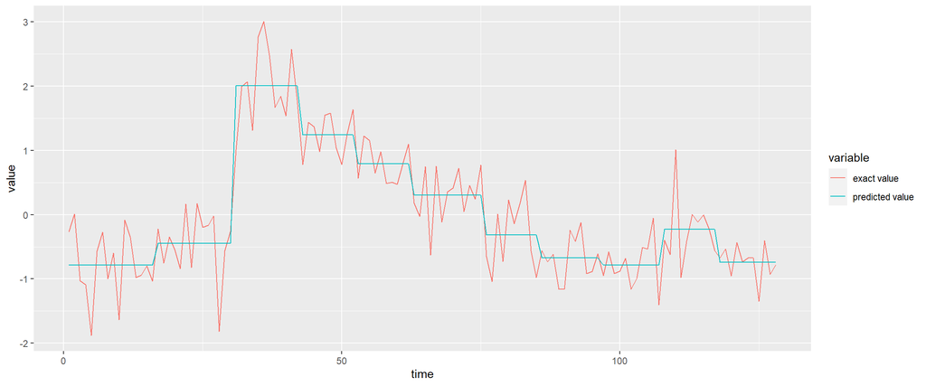

[output not shown]

[output cut: 16 more lines]

### **Question - 3**

We have found the best lambda values for 1D Fused Lasso model and found the best maxdepth values for regression tree model. Then, we are going to calculate the MSE values between the predicted values of each time series both found by 1D Fused Lasso Model and regression tree model and the exact value of each time series. Then, we are going to draw the boxplot of the MSE values of 1D Fused Lasso model and the boxplot of the regression tree model which will be calculated by the MSE function giving the mean squared error between the exact values and the predicted values for each representation for each time series. Let’s see:

[figure not shown]

### **Question - 4**

We have calculated best lambda values for 1D Fused Lasso model, best maxdepth values for regression tree model, MSE values of 1D Fused Lasso model, and regression tree model for each time series. Then, we were requested to calculate and predict the classes of the excluded values in accordance with what we have learnt through different representations. Let’s check the accuracy of the representations (codes are included in as (#…) form in the code, shown below are just the results):

```
##       Exact Class Value Predicted Class Value - 1-NN
##  [1,]                 1                            3
##  [2,]                 1                            1
##  [3,]                 1                            3
##  [4,]                 1                            1
##  [5,]                 1                            1
##  [6,]                 1                            1
##  [7,]                 1                            1
##  [8,]                 1                            1
##  [9,]                 1                            1
## [10,]                 1                            1
## [11,]                 2                            2
## [12,]                 2                            2
## [13,]                 2                            2
## [14,]                 2                            1
```

[output cut: 16 more lines]

```
##       Exact Class Value Predicted Class Value - 1D Fused Lasso
##  [1,]                 1                                      3
##  [2,]                 1                                      1
##  [3,]                 1                                      3
##  [4,]                 1                                      1
##  [5,]                 1                                      1
##  [6,]                 1                                      1
##  [7,]                 1                                      1
##  [8,]                 1                                      1
##  [9,]                 1                                      1
## [10,]                 1                                      3
## [11,]                 2                                      2
## [12,]                 2                                      2
## [13,]                 2                                      2
## [14,]                 2                                      2
```

[output cut: 16 more lines]

[output not shown]

[output cut: 16 more lines]